# Algorithm Beginner Class 11 Lecture - Binary Tree

2018/6/21

# Binary Tree

Definition: at most two children node.

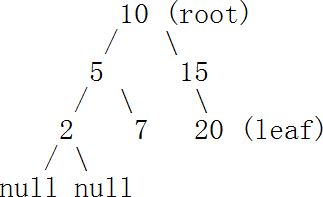

```java
class TreeNode {
  int value;
  TreeNode left;  //by default = null
  TreeNode right;  //by default = null
  TreeNode parent;  //optional: point to this node's parent node
}
```

## 基本知識點1: tree traverse

1. DFS (Depth-first search)
   1. Pre-order: parent before children
   2. In-order: parent in the middle of children
   3. Post-order: parent after children

   > traverse順序不變，變的只是邏輯執行順序
2. BFS (Breadth-first search)
   1. Level by level

## (1) pre-order

```java
public void preOrder(TreeNode root) {
  //base case
  if (root == null) {
    return;
  }

  //print, go left, go right
  System.out.println(root.value);
  preOrder(root.left);
  preOrder(root.right);
}
```

## (2) in-order

```java
public void inOrder(TreeNode root) {
  //base case
  if (root == null) {
    return;
  }

  //go left, print, go right
  inOrder(root.left);
  System.out.println(root.value);
  inOrder(root.right);
}
```

## (3) post-order

```java
public void postOrder(TreeNode root) {
  //base case
  if (root == null) {
    return;
  }

  //go left, go right, print
  postOrder(root.left);
  postOrder(root.right);
  System.out.println(root.value);
}
```

## 基本知識點2

基本概念

- **Height of binary tree**: The distance between the root with the deepest leaf node.
- **Balanced binary tree**: is commonly defined as a binary tree in which the depth (also known as height) of the left and right subtrees of **every node** differ by 1 or less
  1. for each of the nodes in this binary tree
  2. satisfy: the height of leftsubtree, rightsubtree at most diff by 1.

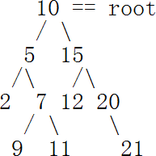

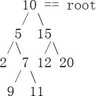

- **Complete binary tree**: is a binary tree in which every level, except possibly the last, is complete filled, and all nodes are as far left as possible.

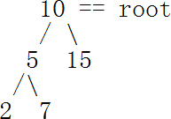

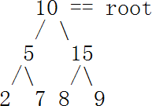

- **Full binary tree**: A full binary tree (sometimes proper binary tree or 2-tree) is a tree in which every node other than the leaves has two children.

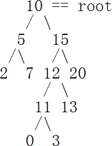

- **Binary Search Tree**: for every single node in the tree, the values in its left **subtree** are all smaller than (or equal to) its value, and the values in its right **subtree** are all larger than (or equal to) its value.

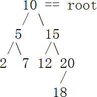

# Discussion

- Binary tree往往是最常見的,和recursion結合最緊密的面試題目類型.
- Reasons:
  - 每層的node具備的性質,傳遞的值和下一層的性質一致(recursion的定義).比較容易定義recursive rule.
  - **Base case** (generally): **null pointer under the leaf node**
  - Example 1: int getHeight(node root)
  - Example 2: 統計tree裡邊有多少個node?
- Fundamental Knowledge:
  - Traversal of a binary tree
    - level by level
    - pre order
    - in order
    - post order
  - Definition
    - Balanced binary tree
    - Complete binary tree
    - Full binary tree
    - Binary search tree (BST)

## Example 1: GetHeight

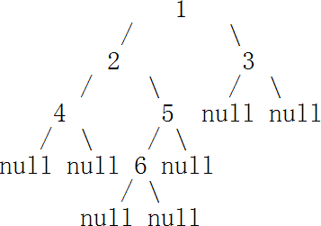

```java
package laioffer;
public class Test {
  public static void main(String[] args) {
    TreeNode t1 = new TreeNode(1);
    TreeNode t2 = new TreeNode(2);
    TreeNode t3 = new TreeNode(3);
    TreeNode t4 = new TreeNode(4);
    TreeNode t5 = new TreeNode(5);
    TreeNode t6 = new TreeNode(6);
    t1.left = t2;
    t1.right = t3;
    t2.left = t4;
    t2.right = t5;
    t5.left = t6;
    Test sol = new Test();
    System.out.println(sol.getHeight(t1));
  }
  public int getHeight(TreeNode root) {
    if (root == null) {
      return 0;
    }
    //post-order
    int left = getHeight(root.left);
    int right = getHeight(root.right);
    //logic
    int height = Math.max(left, right) + 1;
    return height;
  }
}
class TreeNode {
  int value;
  TreeNode left;
  TreeNode right;
  TreeNode parent;  //optional: point to this node's parent node.
  public TreeNode (int v) {
    value = v;
  }
}
```

n個node  
Time: O($n$)  
Space: worst: O($n$); on average: O($\log{n}$)

## Example 2: CountNode

```java
public int countNodes(TreeNode root) {
  if (root == null) {
    return 0;
  }
  int left = countNodes(root.left);
  int right = conutNodes(root.right);
  return 1 + left + right;
}
```

## Problem 1: Check If Binary Tree Is Balanced

```java
public boolean checkBalanced(TreeNode root) {
  //base case,絕大多數情況都能以null節點當base case
  if (root == null) {
    return true;
  }

  //left call, right call
  boolean left = checkBalanced(root.left);
  boolean right = checkBalanced(root.right);

  //logic
  if (!left || !right) {
    return false;
  }

  //judge if the height diff of current node is satisfied
  int leftHeight = getHeight(root.left);
  int rightHeight = getHeight(root.right);
  if (Math.abs(leftHeight - rightHeight) > 1) {
    return false;
  }
  return true;
}
```

Time: O($n\cdot\log{n}$)  
Space: O(height of the tree), on average: O($\log{n}$)